# Pilot 1 Analysis

Matt Jaquiery

08/05/2020

[Script run 2021-04-14 10:53:53]

# Introduction

How we judge our responsibility and the responsibility of others for actions’ outcomes has important consequences in our society. It is tightly related to whether we get rewarded or blamed for the actions we make, which is crucial for the maintenance of a cooperative and fair society. Even in our everyday lives, correctly or wrongfully attributing responsibility to ourselves and others for seemingly non crucial actions, can have emotional and long-term consequences.

How people attribute responsibility to themselves in a group is subjective: They tend to attribute higher responsibility for positive as compared to negative outcomes. This is known as the self-serving bias, where people claim more credit for positive events, while they duck responsibility for negative events (Caine & Schlenker, 1979; Forsyth & Schlenker, 1977; Leary & Forsyth, 1987; Miller & Schlenker, 1985). This bias however does not seem to be purely selfish: it also appears when people judge their group or another person’s responsibility (Palmeira et al., 2015; Taylor & Doria, 1981). For example, in the context of advising, people exhibit an ‘other-serving’ bias as they tend to credit more than blame an advisor (Palmeira et al., 2015).

In individual contexts, the rewards naturally seem to belong to the person producing a positive or negative outcome. In a group decision however, the outcome may be shared or given to one group member. It has been established that responsibility underlies ownership: control and intent of an action, which are directly associated with responsibility attributions, also predict whether a person is perceived as the owner of an object (Palamar et al., 2012). If attributions of responsibility predict ownership, is the opposite true? Here we would like to address 1) whether *Outcome ownership* changes attributions of responsibility and 2) whether *Outcome ownership* is necessary for the self-serving and/or other-serving bias to appear.  
We investigate this question in a group decision-making context, where only one member can receive the outcome in each round.

Participants will perform an online task where they make collective decisions through majority votes, then one member of the group can receive either a *Reward* or *No reward*. Finally they will rate the responsibility of the group members for the outcome. This paradigm will allow us to address both questions stated above:

1. by investigating whether responsibility attribution increases for the *Outcome owner*, although the control over the outcome is exactly similar.
2. By checking whether the self and other-serving bias of higher responsibility ratings for positive outcomes depend on *Outcome ownership*.

In other words, we will answer the question: do people exhibit the same self-serving bias when judging the responsibility for an outcome that is attributed to another member of their group? Do they also still exhibit an ‘other-serving’ bias when judging the responsibility of another group member who did not receive the outcome? We will also investigate (1b) whether self- and other-serving biases are of similar strength.[^1]

The study reported here is the first pilot study. In this study, participants provided a rating of their own responsibility for the outcome on every trial. For consistency with other studies in this series, we describe it as having a 2x2x2x1 factor structure, with all factors within-subjects:

- Whether the rated player is the *Outcome recipient*:
  - *Outcome owner* versus *Not outcome owner*
- The *Outcome valence*:
  - *Reward* versus *No reward*
- The *Vote status* of the participant in the group decision process:
  - *Participant in majority* versus *Participant in minority*
- Whether the *Responsibility judgement* is made about:
  - *Own responsibility* versus *Another’s responsibility*
  - In this experiment all *Responsibility judgements* are made about the participant’s *Own responsibility*

# Method

## Statistical analysis

The primary analysis technique is ANOVA (Bayesian and frequentist). Bayesian ANOVA results are obtained by taking the likelihood of a model with the effect of interest plus all simpler effects compared to an alternative containing only the simpler effects. For main effects, this is the model for the effect alone compared to the intercept-only model; for one-way interactions this is the main effects plus interaction-of-interest model compared to the main effects only model.

## Materials

Experiments were custom-written in HTML/CSS/JavaScript using the [jsPsych framework](https://www.jspsych.org/) and undertaken by participants over the internet using their own devices. The experiment code was written by Marwa El Zein.

## Procedure

The entry point to the study is through recruitment on the Prolific (https://prolific.ac/) participant recruitment platform. Participants accepting the study are forwarded to the experiment website, where they provide informed consent for participation before entering the main experiment page. The experiment begins with detailed instruction pages which describe the structure of each round in the game, with screenshots of each stage, followed by a short training trial sequence. Once they have read the instructions and familiarised themselves with the game, participants begin the main experiment, which consists of 3 blocks of 20 trials. The 20 trials are a randomised sequence of balanced repetitions of each of the 8 unique trial types (as defined by whether the outcome is a reward/no reward; whether the participant is in the majority/minority; and whether the participant receives the outcome). The a reward/no reward trials and the trials with the participant in the majority/minority occurred equally frequently, while the participant received the outcome on 40% of all trials (because we wanted to maximise this variation but felt that 50% of trials might be noticeably unrealistic with four other players in the game).

Each trial begins with a display of the five players. This is followed by a screen in which the participant selects one of two gamble images. Gamble images are selected from a collection of hand-drawn images of gambling devices and paraphernalia, and are counterbalanced such that each pair of images is shown the same number of times. Which gamble is selected has no influence on the outcome of the trial, which is predetermined. Once the participant selects a gamble the other option vanishes.

If the participant has not selected a gamble by the end of the choice window, the rest of the trial is cancelled and the participant is shown a warning message which states that they have failed to make a choice in time. If the participant did select a gamble, the next screen indicates which gamble has been selected through the majority vote of all five players. Next, the gamble is allocated to one of the players and its outcome is shown (a coin for a rewarded trial or a coin with a cross through it for an unrewarded trial).

Finally, the participant is asked to rate their own responsibility for the outcome using a slider. The responsibility rating phase lasts until the responsibility rating has been submitted.

Once all 60 experimental trials have been completed, participants are debriefed, thanked, and returned to Prolific. Payment follows once all participants have completed the study and bonuses have been calculated.

## Open science

### Preregistration

Experiment 1 was not preregistered due to a technical glitch with the Open Science Framework platform (OSF). The preregistration form was submitted, but it was never processed and added to the repository.

### Open materials

Materials for the studies can be found on the [GitHub repository](https://github.com/mjaquiery/responsibility-by-reward/tree/d6e65c5f4b62becfa23054c8e124d8916382b446/ATTRRESP) as it stood on 4th May 2020.

### Open data

Data for this pilot experiment are stored in two separate .csv files on GitHub. The first 50 participants were recruited initially, then the remaining participants were recruited after investigating the data using Bayesian tests.  
* [First 50 participants](https://raw.githubusercontent.com/mjaquiery/responsibility-by-reward/master/data/data50part.csv)  
* [Remaining participants](https://raw.githubusercontent.com/mjaquiery/responsibility-by-reward/master/data/dataextra.csv)

# Results

## Descriptive statistics

### Exclusions

(#tab:exclusions)

| Reason | N excluded |
| --- | --- |
| double_entry | 1.00 |
| missed_trials | 11.00 |
| trial_count | 3.00 |
| consec_resp | 4.00 |
| total_unique_exclusions | 18.00 |

Before exclusion we have 72 subject_ids. We now exclude participants who have more than 10 missed trials, picked the gamble option on the same side for all the trials in a block (after removing incomplete responses),[^2] or fewer than 60 trials recorded. Our final participant list contains 54 participants.

### Demographics

(#tab:participant demographics)

| gender | n |
| --- | --- |
| F | 26 |
| M | 28 |

Participants self-reported a mean age of 24.6 (SD = 5) years and their genders as M (28), F (26), or otherwise (0).

Data were collected on the following days:

(#tab:experiment dates)

| Date | Participants |
| --- | --- |
| 04/05/2020 | 37 |
| 08/05/2020 | 17 |

### Response times

Participants make two responses on a trial, choosing a gamble and indicating their feeling of responsibility. The distributions of the timings of these events for each participant are shown below for the first 15 seconds of the trials. The 20 responses which took longer than 15 seconds have been removed from this plot (the number for each participant is indicated in grey text), but remain in the responsibility rating data analysed in the main analysis.

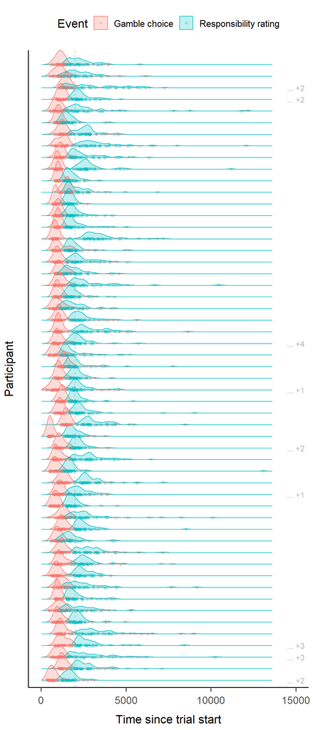

### Feeling of responsibility scale usage

This plot shows each participant’s use of the responsibility rating scale, i.e. their answers to the question of how responsible they felt on each trial.

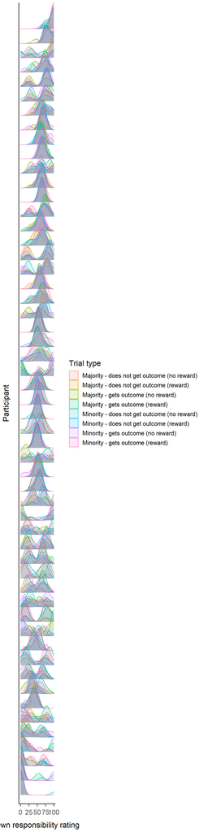

## Inferential statistics

The key analysis is an ANOVA exploring the effects of who gets the trial outcome and what that outcome is (and also whether the participant votes with the majority). The dependent variable is the participant’s rating of their own responsibility for the decision.

(#tab:ANOVA results)

|  | Effect | DFn | DFd | F | p | p<.05 | ges |
| --- | --- | --- | --- | --- | --- | --- | --- |
| ANOVA |  |  |  |  |  |  |  |
| 2 | outcome | 1.00 | 53.00 | 28.46 | 0.00 | * | 0.03 |
| 3 | getsout | 1.00 | 53.00 | 15.48 | 0.00 | * | 0.02 |
| 4 | status | 1.00 | 53.00 | 0.05 | 0.82 |  | 0.00 |
| 5 | outcome:getsout | 1.00 | 53.00 | 9.46 | 0.00 | * | 0.00 |
| 6 | outcome:status | 1.00 | 53.00 | 5.29 | 0.03 | * | 0.01 |
| 7 | getsout:status | 1.00 | 53.00 | 0.10 | 0.76 |  | 0.00 |
| 8 | outcome:getsout:status | 1.00 | 53.00 | 7.64 | 0.01 | * | 0.00 |

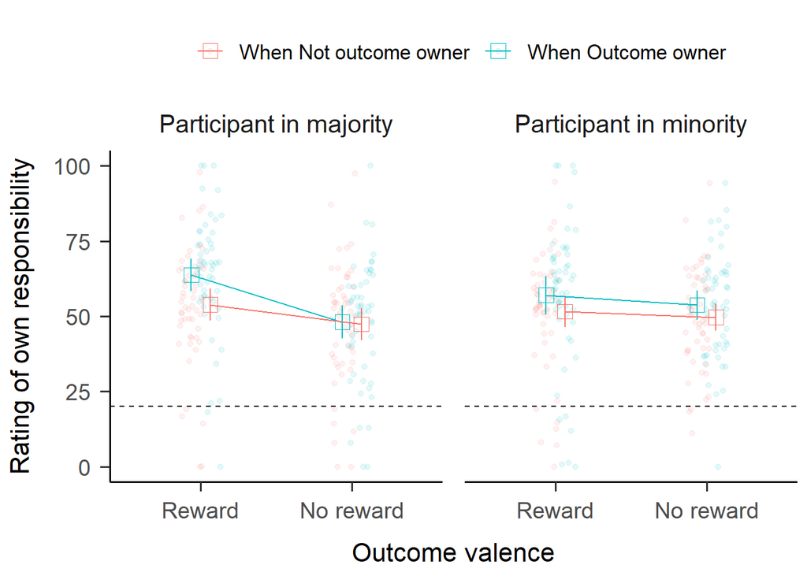

The figure shows participant mean self-responsibility ratings collapsed in each trial type (coloured dots). Squares indicate the mean for a trial type across all participant means, with the error bars giving 95% confidence intervals.

Below we unfold these results with a plot for each hypothesis.

### 1) Do participants feel more responsible if they are the *Outcome owner*?

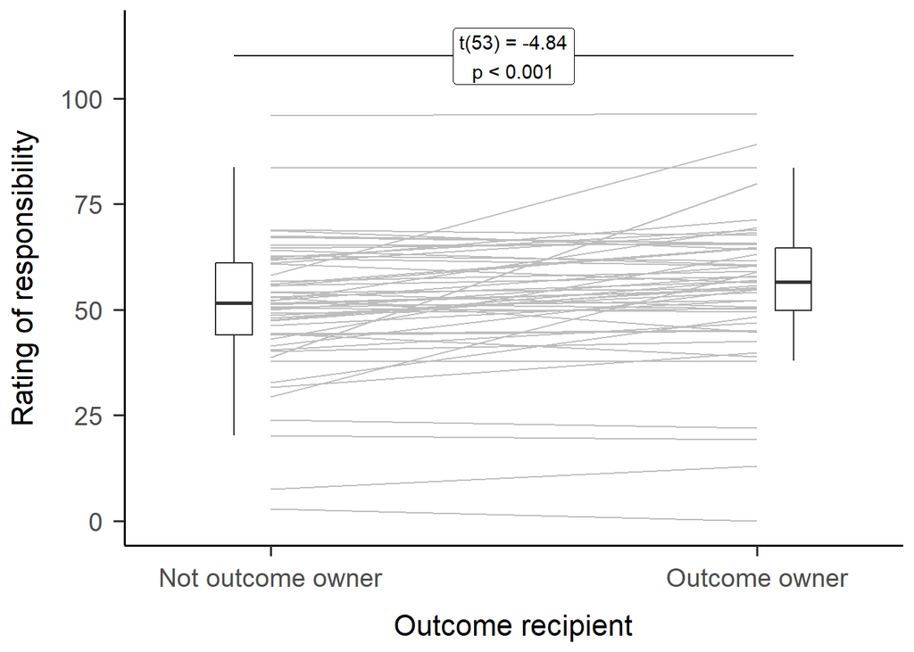

The figure shows participant mean self-responsibility ratings collapsed across other trial factors (lines) and their distributions (box plots). Participants rate their own responsibility as higher when they (rather than another participant) receive the outcome.

### 2) Does the self-serving bias, i.e, higher responsibility for positive *Outcome valence*, change if the participant is *Not outcome owner*?

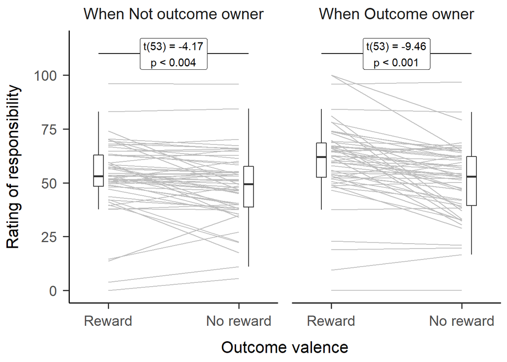

The figure shows participant mean self-responsibility ratings collapsed across other trial factors (lines) and their distributions (box plots). The effect of ‘self-serving bias’ seems more pronounced on trials where the participant gets the outcome than on trials where another player gets the outcome.

## Bayesian ANOVA

Bayesian ANOVA formed part of our original plans, but we have sidelined it because we found the frequentist version to be more interpretable in our final experimental design. It is included here for transparency.

(#tab:Bayesian ANOVA results)

| M1 | M2 | BF.M1.M2 |  |
| --- | --- | --- | --- |
| status + outcome + getsout + subject_id | status + getsout + subject_id | 145,208,922,484.55 | + |
| status + outcome + getsout + subject_id | status + outcome + subject_id | 635,621.40 | + |
| status + outcome + getsout + subject_id | outcome + getsout + subject_id | 0.04 | - |
| status + outcome + getsout + outcome:getsout + subject_id | status + outcome + getsout + subject_id | 7.40 | + |
| status + outcome + status:outcome + getsout + subject_id | status + outcome + getsout + subject_id | 5,742.97 | + |
| status + outcome + getsout + status:getsout + subject_id | status + outcome + getsout + subject_id | 0.06 | - |
| status + outcome + status:outcome + getsout + status:getsout + outcome:getsout + status:outcome:getsout + subject_id | status + outcome + status:outcome + getsout + status:getsout + outcome:getsout + subject_id | 1.35 |  |

# Interpretation

# References

Bruce T. Caine and Barry R. Schlenker. Role Position and Group Performance as Determinants of Egotistical Perceptions in Cooperative Groups. The Journal of Psychology, 101(2):149–156, March 1979. ISSN0022-3980. doi: 10.1080/00223980.1979.9915066. URL https://doi.org/10.1080/00223980.1979.9915066.

John M. Darley and Bibb Latane. Bystander intervention in emergencies: Diffusion of responsibility. Journal of Personality and Social Psychology, 8(4, Pt.1):377–383,1968. ISSN 1939-1315(Electronic), 0022-3514(Print). doi: 10.1037/h0025589.

Donelson R. Forsyth, Linda E. Zyzniewski, and Cheryl A. Giammanco. Responsibility Diffusion in Cooperative Collectives. Personality and Social PsychologyBulletin, 28(1):54–65, January 2002. ISSN 0146-1672. doi:10.1177/0146167202281005.URL https://doi.org/10.1177/0146167202281005.

Donelson R. Forsyth and Barry R. Schlenker. Attributing the causes of group performance: Effects of performance quality, task importance, and future testing. Journal of Personality, 45(2):220–236, 1977. ISSN 1467-6494(Electronic), 0022-3506(Print). doi:10.1111/j.1467-6494.1977.tb00148.x.

Mark R. Leary and Donelson R. Forsyth. Attributions of responsibility for collective endeavors. In Group processes, Review of personality and social psychology, Vol. 8., pages167–188. Sage Publications, Inc, Thousand Oaks, CA, US,1987. ISBN 978-0-8039-3071-1 978-0-8039-3072-8.

Rowland S. Miller and Barry R. Schlenker. Egotism in Group Members: Public and Private Attributions of Responsibility for Group Performance. Social Psychology Quarterly, 48(1):85–89,1985. ISSN 0190-2725.doi:10.2307/3033785. URL https://www.jstor.org/stable/3033785.

Mauricio Palmeira, Gerri Spassova, and Hean TatKeh. Other-serving bias in advice-taking: When advisors receive more credit than blame. Organizational Behavior and Human Decision Processes, 130:13–25, September 2015. ISSN 0749-5978.doi:10.1016/j.obhdp.2015.06.001. URL http://www.sciencedirect.com/science/article/pii/S0749597815000692.

Max Rollwage, Franziska Pannach, Caedyn Stinson, Ulf Toelch, Igor Kagan, and Arezoo Pooresmaeili. Judgments of effort exerted by others are influenced by received rewards. Scientific Reports, 10(1):1–14, February 2020. ISSN 2045-2322. doi: 10.1038/s41598-020-58686-0. URLhttps://www.nature.com/articles/s41598-020-58686-0.

Donald M. Taylor and Janet R. Doria. Self-Serving and Group-Serving Bias in Attribution. The Journal of Social Psychology, 113(2):201–211, April 1981. ISSN0022-4545. doi: 10.1080/00224545.1981.9924371. URL https://doi.org/10.1080/00224545.1981.9924371. Publisher: Routledge_eprint: https://doi.org/10.1080/00224545.1981.9924371.

# Credits

## R Packages

(#tab:R packages)

| Package | Citations |
| --- | --- |
| base | R Core Team (2020). R: A language and environment for statistical computing. R Foundation for Statistical Computing, Vienna, Austria. URL https://www.R-project.org/. |
| papaja | Aust, F. & Barth, M. (2020). papaja: Prepare reproducible APA journal articles with R Markdown. R package version 0.1.0.9997, retrieved from https://github.com/crsh/papaja |
| BayesFactor | Richard D. Morey and Jeffrey N. Rouder (2018). BayesFactor: Computation of Bayes Factors for Common Designs. R package version 0.9.12-4.2. https://CRAN.R-project.org/package=BayesFactor |
| Matrix | Douglas Bates and Martin Maechler (2019). Matrix: Sparse and Dense Matrix Classes and Methods. R package version 1.2-18. https://CRAN.R-project.org/package=Matrix |
| coda | Martyn Plummer, Nicky Best, Kate Cowles and Karen Vines (2006). CODA: Convergence Diagnosis and Output Analysis for MCMC, R News, vol 6, 7-11 |
| ez | Michael A. Lawrence (2016). ez: Easy Analysis and Visualization of Factorial Experiments. R package version 4.4-0. https://CRAN.R-project.org/package=ez |
| ggridges | Claus O. Wilke (2020). ggridges: Ridgeline Plots in ‘ggplot2’. R package version 0.5.2. https://CRAN.R-project.org/package=ggridges |
| forcats | Hadley Wickham (2020). forcats: Tools for Working with Categorical Variables (Factors). R package version 0.5.0. https://CRAN.R-project.org/package=forcats |
| stringr | Hadley Wickham (2019). stringr: Simple, Consistent Wrappers for Common String Operations. R package version 1.4.0. https://CRAN.R-project.org/package=stringr |
| dplyr | Hadley Wickham, Romain François, Lionel Henry and Kirill Müller (2020). dplyr: A Grammar of Data Manipulation. R package version 1.0.0. https://CRAN.R-project.org/package=dplyr |
| purrr | Lionel Henry and Hadley Wickham (2020). purrr: Functional Programming Tools. R package version 0.3.4. https://CRAN.R-project.org/package=purrr |
| readr | Hadley Wickham, Jim Hester and Romain Francois (2018). readr: Read Rectangular Text Data. R package version 1.3.1. https://CRAN.R-project.org/package=readr |
| tidyr | Hadley Wickham and Lionel Henry (2020). tidyr: Tidy Messy Data. R package version 1.1.0. https://CRAN.R-project.org/package=tidyr |
| tibble | Kirill Müller and Hadley Wickham (2020). tibble: Simple Data Frames. R package version 3.0.1. https://CRAN.R-project.org/package=tibble |
| ggplot2 | H. Wickham. ggplot2: Elegant Graphics for Data Analysis. Springer-Verlag New York, 2016. |
| tidyverse | Wickham et al., (2019). Welcome to the tidyverse. Journal of Open Source Software, 4(43), 1686, https://doi.org/10.21105/joss.01686 |

## Funding

Marwa El Zein is a Sir Henry Wellcome Postdoctoral Fellow at University College London, funded by The Wellcome Trust (grant number 204702).

Matt Jaquiery is funded by a studentship from the [Medical Research Council](https://mrc.ukri.org/) (reference 1943590) and the University of Oxford [Department of Experimental Psychology](https://www.psy.ox.ac.uk/) (reference 17/18_MSD_661552).

## Technical details

[^1]: This is not investigated in Pilot 1 because all responsibility ratings are given for the participant themselves.
[^2]: *Note*: The criterion for exclusion of participants for consecutive responses was preregistered as 10 consecutive trials with the same gamble response key. It was not clear in our preregistration planning whether trials with no response should break up consecutive responses for this purpose. After determining that the particular implementation of this exclusion rule did not change the interpretations drawn from the analysis results and that consecutive gamble choice did not seem to be a marker of inattention, we instead adopted the simpler rule that all participants must have used both gamble choice response keys in every block of trials.